# 1. The Monkeys

The present study assessed a sample of 147 monkeys who had a mean age of 16.22 (SD = 5.06). Of the monkeys surveyed, 33.33% were the species Bonobo, 34.01% were Capuchin, and 32.65% were Macaque, with 54.42% having been reared in captivity and 45.58% in the wild. The monkeys were assessed on personality, and were found to have a mean dominance score of 0.07 (SD = 1.01). Prior to analysis data was cleaned and all missing or incorrect values were either removed from the data set or corrected.

The researchers were interested in finding out whether distribution of wild and captive rearings were evenly distributed across species, so a chi-square test of independence was run on species and rearing. Assumptions were met, as there were 2 or more levels in each variable, observations were independent, and expected frequencies were all above 1 and were above 5 in 80% of cases. The chi-square test found that distribution of wild and captive rearings were not significantly different across species ($p$=0.169). This suggested that the distribution of monkeys being reared in captivity or in the wild was approximately evenly distributed across species.

Researchers were also interested in whether or not dominance levels differed between monkeys raised in the wild compared to those raised in captivity. An independent t-test was planned to assess this. A Shapiro test found assumptions of normality were met for dominance levels in the group reared in captivity, however the Shapiro run on dominance levels in the group reared in the wild found this data violated the assumption of normality. Due to this assumption being violated, a non-parametric Mann-Whitney U test was run in place of an independent t-test. Captive monkeys had a mean dominance score of -0.08 and wild monkeys had one of 0.24, however the Mann-Whitney U test found that the difference between dominance levels was not significantly different ($p$=0.128).

Observed Frequencies of Sharing Behaviour by Species

|  | Bonobo | Capuchin | Macaque |
| --- | --- | --- | --- |
| Didn’t Share | 26 | 19 | 31 |
| Did Share | 23 | 31 | 17 |

**Figure 1: Table of Sharing Behaviour by Monkey Species**

# 2. Monkey see, monkey do

Regression Coefficients For Model of Outcome Time Taken

| Predictor | Coefficient | SE | t | p |
| --- | --- | --- | --- | --- |
| Intercept | 13.60 | 1.575 | 8.64 | <0.001 |
| Species Capuchin | -1.93 | 0.811 | -2.38 | 0.018 |
| Species Macaque | -0.23 | 0.866 | -0.26 | 0.795 |
| Rearing Wild | 1.44 | 2.360 | 0.61 | 0.544 |
| Age | -0.15 | 0.077 | -1.95 | 0.054 |
| Dominance | -0.92 | 0.393 | -2.35 | 0.020 |
| Species Capuchin : Rearing Wild | -1.23 | 1.275 | -0.97 | 0.336 |
| Species Macaque : Rearing Wild | -0.92 | 1.342 | -0.69 | 0.493 |
| Rearing Wild : Age | 0.12 | 0.146 | 0.81 | 0.421 |
| Species Capuchin : Dominance | -0.19 | 0.613 | -0.30 | 0.762 |
| Species Macaque : Dominance | -2.88 | 0.668 | -4.32 | <0.001 |

**Figure 2: Table of Regression Coefficients For Outcome of Time Taken to Complete Task**

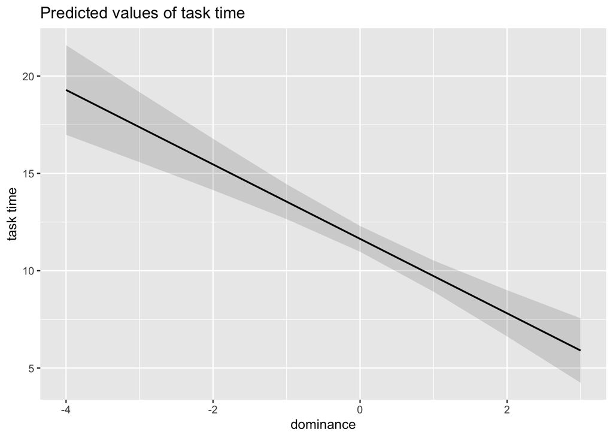

**Figure 3: Plot Showing Model of Dominance Level and Predicted Task Time**

# 3. Monkey business

The second research question of interest to the researchers was to explore the main predictors of whether or not the monkeys would share the food following the problem-solving task. Since this was a binary outcome, a logistic generalised linear regression model was fitted to the data. The regression analysis was fitted with sharing behaviour as the outcome, and the predictors of interest to the researchers as well as those already established by previous research. The predictors of interest were dominance, species, and the interaction between these. The predictors backed by previous research were species, rearing, age, the interaction between rearing and species, and the interaction between rearing and age. After the regression model was fitted to the data, a plot of studentized deviant residuals was observed with no points being above two, indicating the assumption of normality was met.

Regression Coefficients For Model of Outcome Sharing Behaviour

| Predictor | Exponential Coefficient | SE | z | p |
| --- | --- | --- | --- | --- |
| Intercept | 1.29 | 1.140 | 0.23 | 0.822 |
| Species Capuchin | 2.58 | 0.562 | 1.69 | 0.092 |
| Species Macaque | 1.05 | 0.614 | 0.09 | 0.931 |
| Rearing Wild | 2.02 | 1.681 | 0.42 | 0.676 |
| Age | 0.95 | 0.057 | -0.84 | 0.400 |
| Dominance | 0.73 | 0.282 | -1.13 | 0.257 |
| Species Capuchin : Rearing Wild | 0.29 | 0.911 | -1.37 | 0.170 |
| Species Macaque : Rearing Wild | 0.16 | 0.951 | -1.92 | 0.055 |
| Rearing Wild : Age | 1.05 | 0.104 | 0.49 | 0.623 |
| Species Capuchin : Dominance | 1.96 | 0.436 | 1.55 | 0.122 |
| Species Macaque : Dominance | 3.01 | 0.486 | 2.27 | 0.023 |

**Figure 4: Table of Regression Coefficients For Outcome of Sharing Behaviour**

Due to the nature of logistic regression, Figure 4 shows the exponential coefficients which can be more easily interpreted in terms of odds. The intercept shows that the odds of a monkey sharing would be 1.29 if they were an age zero Bonobo, reared in captivity, with a dominance score of zero. The regression model had no significant individual effects, but one significant interaction effect. This was an interaction between the Macaque species and dominance. Compared to Bonobos, a one unit increase of dominance in Macaques would be associated with increased odds of sharing by 3.01 ($z$=2.27, $p$=0.023). This suggests that for Macaques higher dominance levels are associated with higher odds of sharing behaviour, whereas higher dominance in Bonobos is associated with lower odds of sharing. This effect is illustrated in Figure 5. It is worth noting that neither species nor dominance had a significant individual effect on the outcome of sharing.

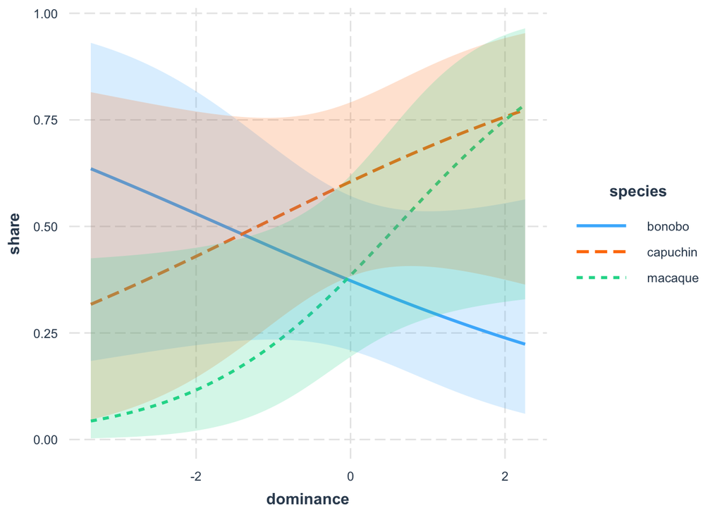

**Figure 5: Plot Showing Interaction Effect Between Species and Dominance Levels on Outcome of Sharing**

A baseline model was also fitted to the data, including only the factors which were backed up by past research. Despite finding a significant interaction effect the model fitted to the outcome of sharing behaviour did not explain a significant additional amount of variance over the baseline model ($p$=0.073).

The chi-square test run earlier found a significant difference between species and sharing behaviour, however in this model species did not have a significant individual effect on sharing behaviour. We can interpret that with the other factors accounted for in the regression model, the association between species and sharing no longer holds. It is possible that the association was impacted by the interaction between species and dominance that the regression model found.

The final question the researchers wished to answer involved using the model to predict the probability of a specific monkey engaging in sharing behaviour. The monkey in question was a 15 year old Bonobo raised in the wild who had a neuroticism level 1 standard deviation above average. Since the monkey’s dominance score was unknown, it was input into the model as the mean dominance level. The model predicts a 0.73 likelihood that the monkey the researchers are interested will share the food following the problem-solving task.

In conclusion, the researchers’ variables of interest did increase the amount of variance explained in the outcome of time taken to complete the problem solving task, but there was not a significant increase in variance explained when the variables were added to the model predicting sharing behaviour.